# Verzani Problem Set

Next are considered the problems from Verzani’s book on page 31

### Problem 4.1

A student evaluation of a teacher is on a 1-5 Leichert scale. Suppose the answers to the first 3 questions are given in this table

| Student | Question 1 | Question 2 | Question 3 |
| --- | --- | --- | --- |
| 1 | 3 | 5 | 1 |
| 2 | 3 | 2 | 3 |
| 3 | 3 | 5 | 1 |
| 4 | 4 | 5 | 1 |
| 5 | 3 | 2 | 1 |
| 6 | 4 | 2 | 3 |
| 7 | 3 | 5 | 1 |
| 8 | 4 | 5 | 1 |
| 9 | 3 | 4 | 1 |
| 10 | 4 | 2 | 1 |

Enter in the data for questions 1, 2 and 3

```r
> q1 <- factor(c(3, 3, 3, 4, 3, 4, 3, 4, 3, 4), levels = c(1, 2, 3, 4, 5))
> q2 <- factor(c(5, 2, 5, 5, 2, 2, 5, 5, 4, 2), levels = c(1, 2, 3, 4, 5))
> q3 <- factor(c(1, 3, 1, 1, 1, 3, 1, 1, 1, 1), levels = c(1, 2, 3, 4, 5))
> eval <- data.frame(q1, q2, q3)
```

1. Make a table of the results of questions 1, 2 and 3 separately

```r
> table(q1)
q1
1 2 3 4 5
0 0 6 4 0
> table(q2)
q2
1 2 3 4 5
0 4 0 1 5
> table(q3)
q3
1 2 3 4 5
8 0 2 0 0
```

2. Make a contingency table of questions 1 and 2

```r
> table(q1, q2)
   q2
q1  1 2 3 4 5
  1 0 0 0 0 0
  2 0 0 0 0 0
  3 0 2 0 1 3
  4 0 2 0 0 2
  5 0 0 0 0 0
```

3. Make a stacked barplot of questions 2 and 3

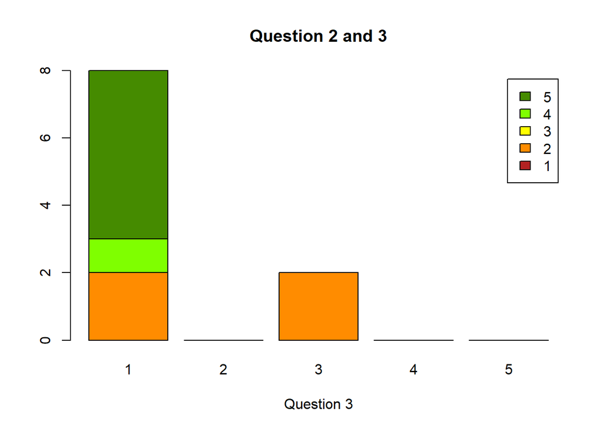

```r
> barplot(table(q2, q3),
+         main = "Question 2 and 3",
+         xlab = "Question 3",
+         col = c("firebrick", "darkorange", "yellow", "chartreuse", "chartreuse4"),
+         legend.text = c(1, 2, 3, 4, 5))
```

4. Make a side-by-side barplot of all 3 questions

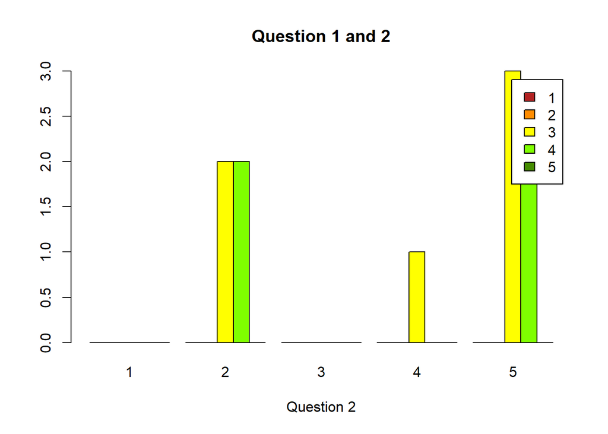

```r
> barplot(table(q1, q2),
+         beside = TRUE,
+         main = "Question 1 and 2",
+         xlab = "Question 2",
+         col = c("firebrick", "darkorange", "yellow", "chartreuse", "chartreuse4"),
+         legend.text = c(1, 2, 3, 4, 5))
```

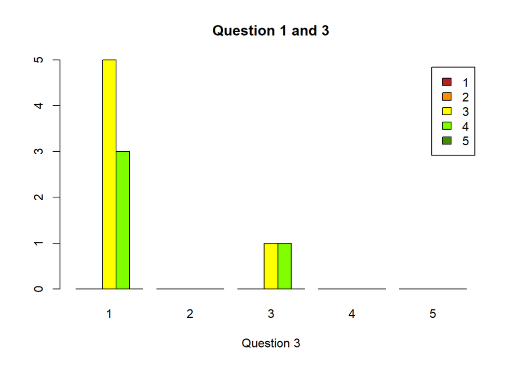

```r
> barplot(table(q1, q3),
+         beside = TRUE,
+         main = "Question 1 and 3",
+         xlab = "Question 3",
+         col = c("firebrick", "darkorange", "yellow", "chartreuse", "chartreuse4"),
+         legend.text = c(1, 2, 3, 4, 5))
```

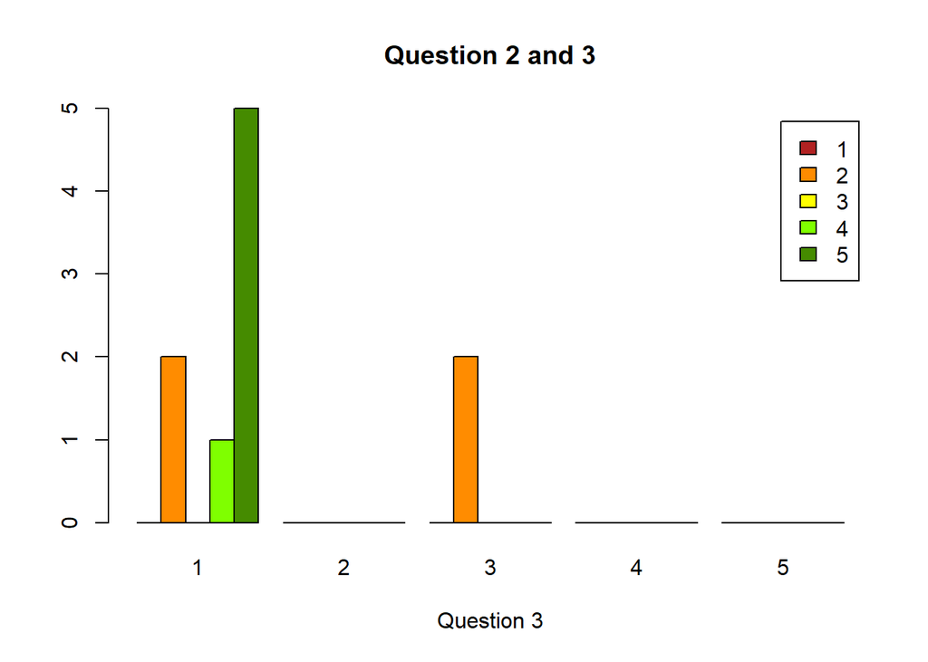

```r
> barplot(table(q2, q3),
+         beside = TRUE,
+         main = "Question 2 and 3",
+         xlab = "Question 3",
+         col = c("firebrick", "darkorange", "yellow", "chartreuse", "chartreuse4"),
+         legend.text = c(1, 2, 3, 4, 5))
```

### Problem 4.2

In the library `MASS` there is a data frame `UScereal` which contains information about popular breakfast cereals. Attach the data set as follows

```r
> library(MASS)
> attach(UScereal)
> names(UScereal)
 [1] "mfr"       "calories"  "protein"   "fat"       "sodium"    "fibre"
 [7] "carbo"     "sugars"    "shelf"     "potassium" "vitamins"
```

Now, investigate the following relationships, and make comments on what you see. You can use tables, barplots, scatterplots etc. to do your investigation.

1. The relationship between manufacturer and shelf

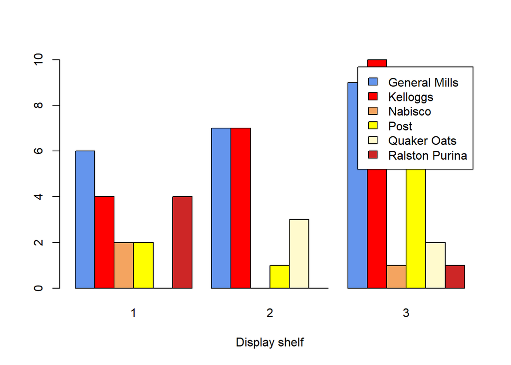

```r
> table(mfr, shelf)
   shelf
mfr  1  2  3
  G  6  7  9
  K  4  7 10
  N  2  0  1
  P  2  1  6
  Q  0  3  2
  R  4  0  1
> barplot(table(mfr, shelf),
+         beside = TRUE,
+         legend.text = c("General Mills", "Kelloggs", "Nabisco", "Post", "Quaker Oats", "Ralston Purina"),
+         col = c("cornflowerblue", "red", "sandybrown", "yellow1", "lemonchiffon", "firebrick3"),
+         xlab = "Display shelf")
```

2. The relationship between fat and vitamins

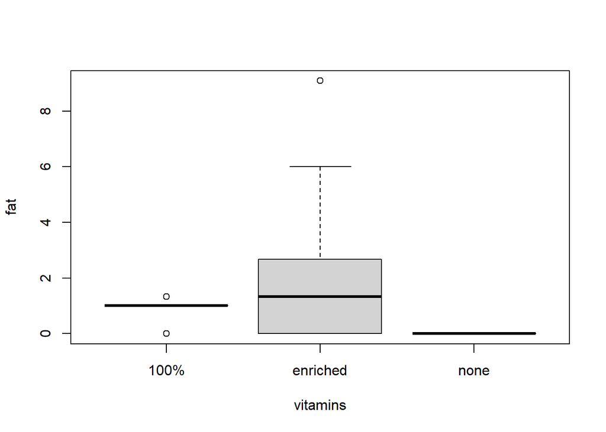

```r
> boxplot(fat ~ vitamins)
```

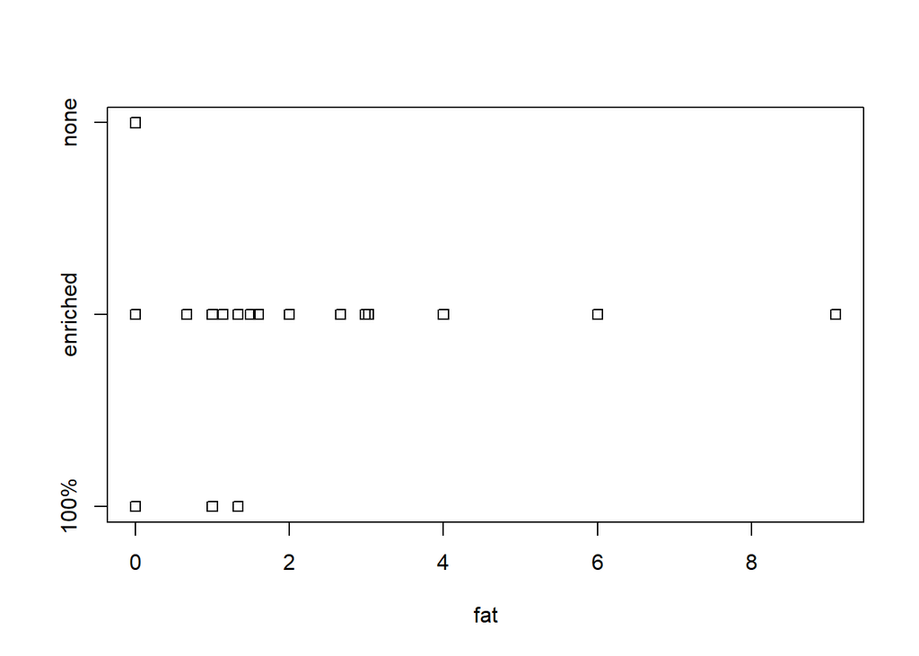

```r
> stripchart(fat ~ vitamins)
```

3. The relationship between fat and shelf

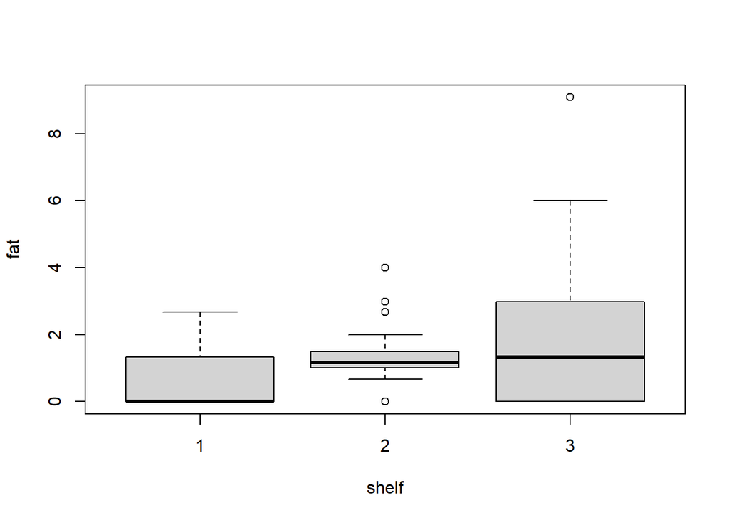

```r
> boxplot(fat ~ shelf)
```

4. The relationship between carbohydrates and sugars

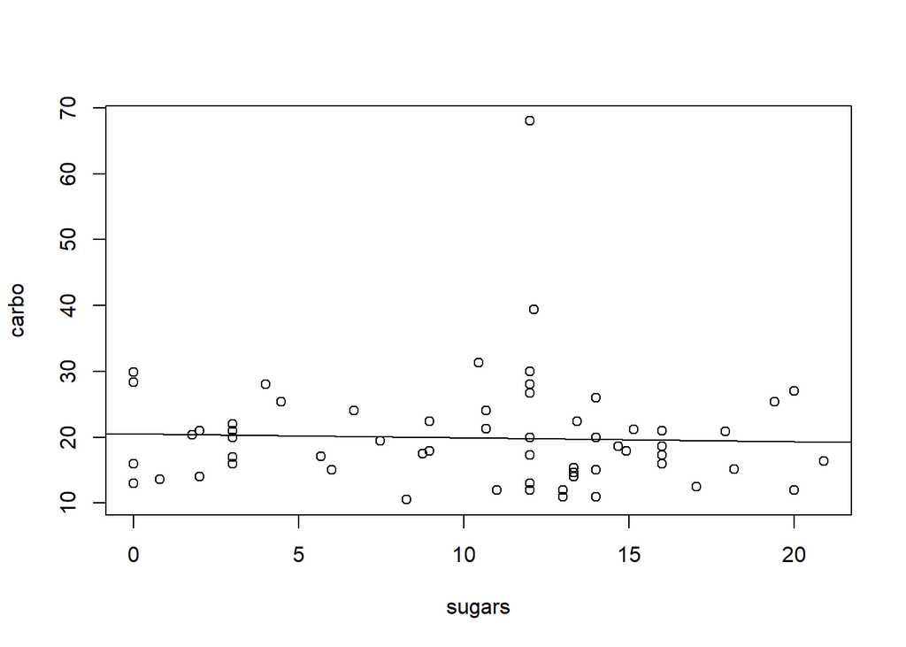

```r
> cor(sugars, carbo)
[1] -0.04082599
> plot(sugars, carbo)
> abline(lm(carbo~sugars))
```

5. The relationship between fibre and manufacturer

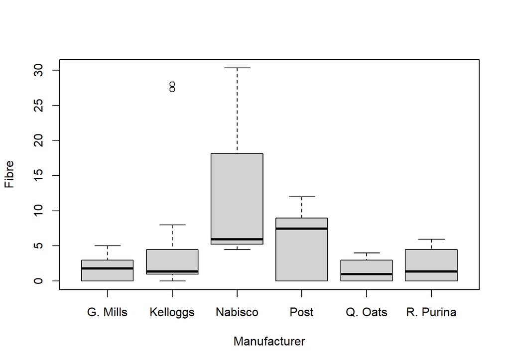

```r
> boxplot(fibre ~ mfr,
+         names = c("G. Mills", "Kelloggs", "Nabisco", "Post", "Q. Oats", "R. Purina"),
+         xlab = "Manufacturer", ylab = "Fibre")
```

6. The relationship between sodium and sugars

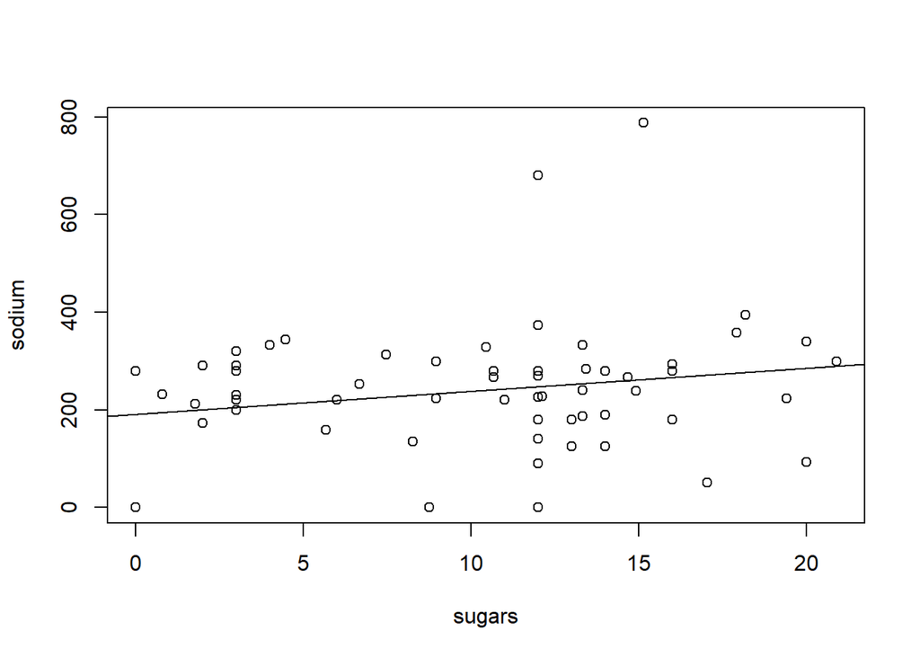

```r
> cor(sugars, sodium)
[1] 0.2112437
> plot(sugars, sodium)
> abline(lm(sodium~sugars))
```

Are there other relationships you can predict and investigate?

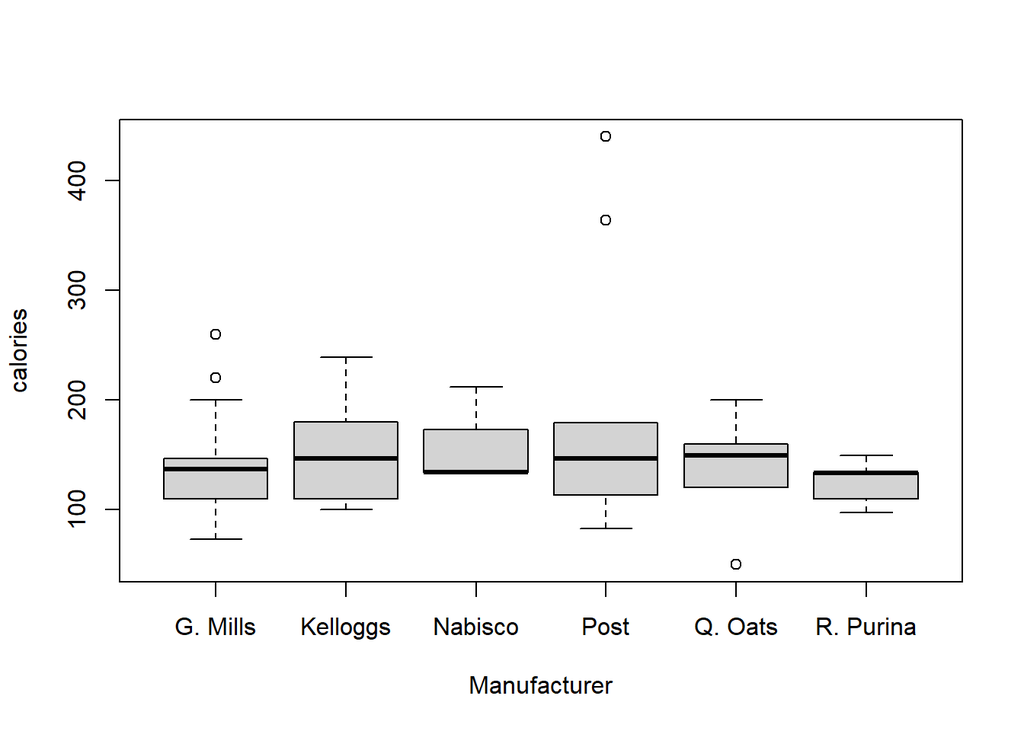

```r
> boxplot(calories ~ mfr,
+         names = c("G. Mills", "Kelloggs", "Nabisco", "Post", "Q. Oats", "R. Purina"),
+         xlab = "Manufacturer")
```

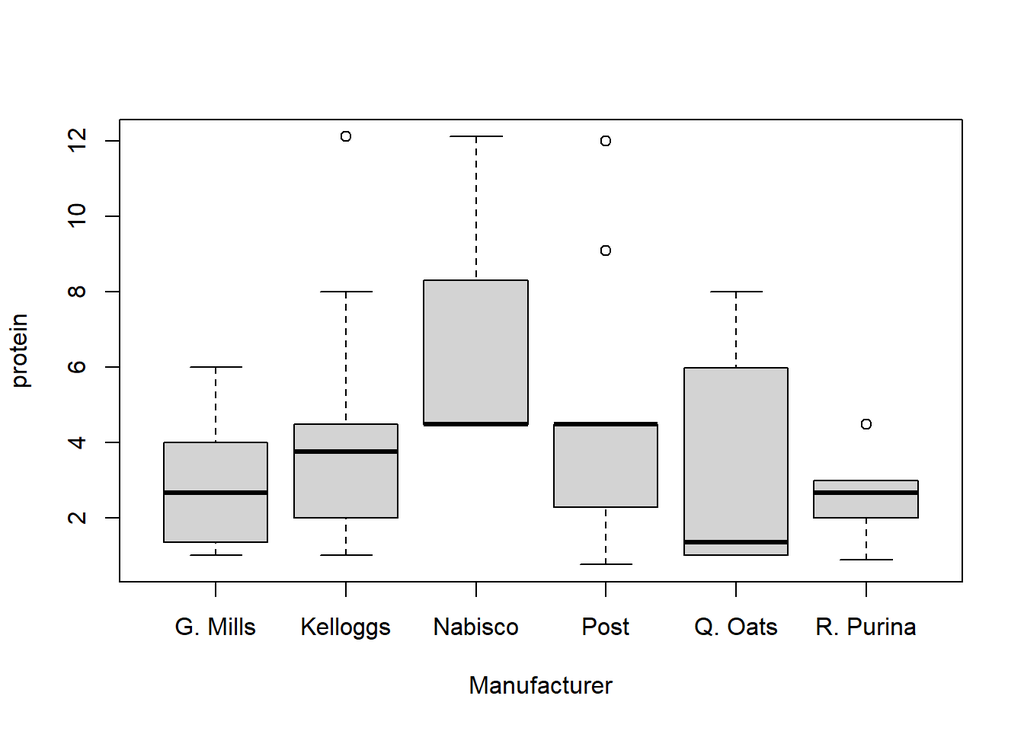

```r
> boxplot(protein ~ mfr,
+         names = c("G. Mills", "Kelloggs", "Nabisco", "Post", "Q. Oats", "R. Purina"),
+         xlab = "Manufacturer")
```

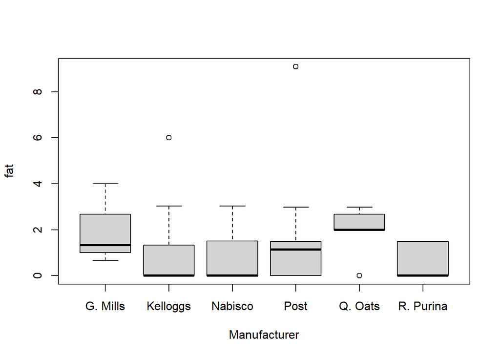

```r
> boxplot(fat ~ mfr,
+         names = c("G. Mills", "Kelloggs", "Nabisco", "Post", "Q. Oats", "R. Purina"),
+         xlab = "Manufacturer")
```

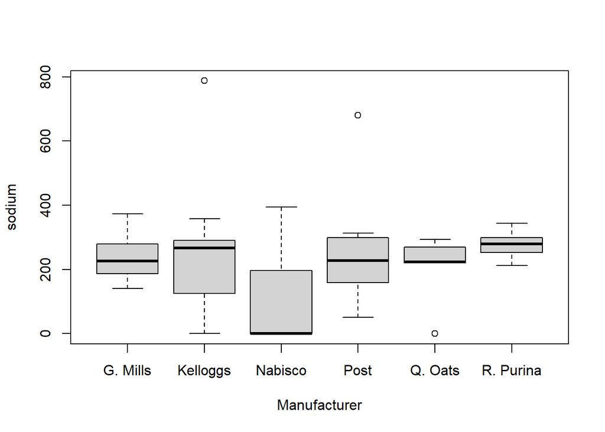

```r
> boxplot(sodium ~ mfr,
+         names = c("G. Mills", "Kelloggs", "Nabisco", "Post", "Q. Oats", "R. Purina"),
+         xlab = "Manufacturer")
```

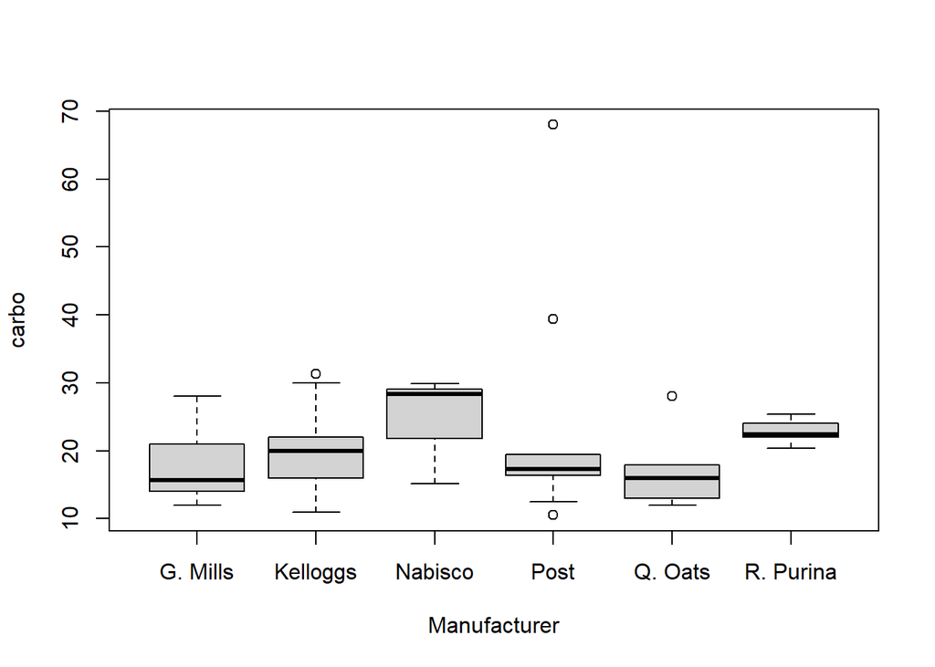

```r
> boxplot(carbo ~ mfr,
+         names = c("G. Mills", "Kelloggs", "Nabisco", "Post", "Q. Oats", "R. Purina"),
+         xlab = "Manufacturer")
```

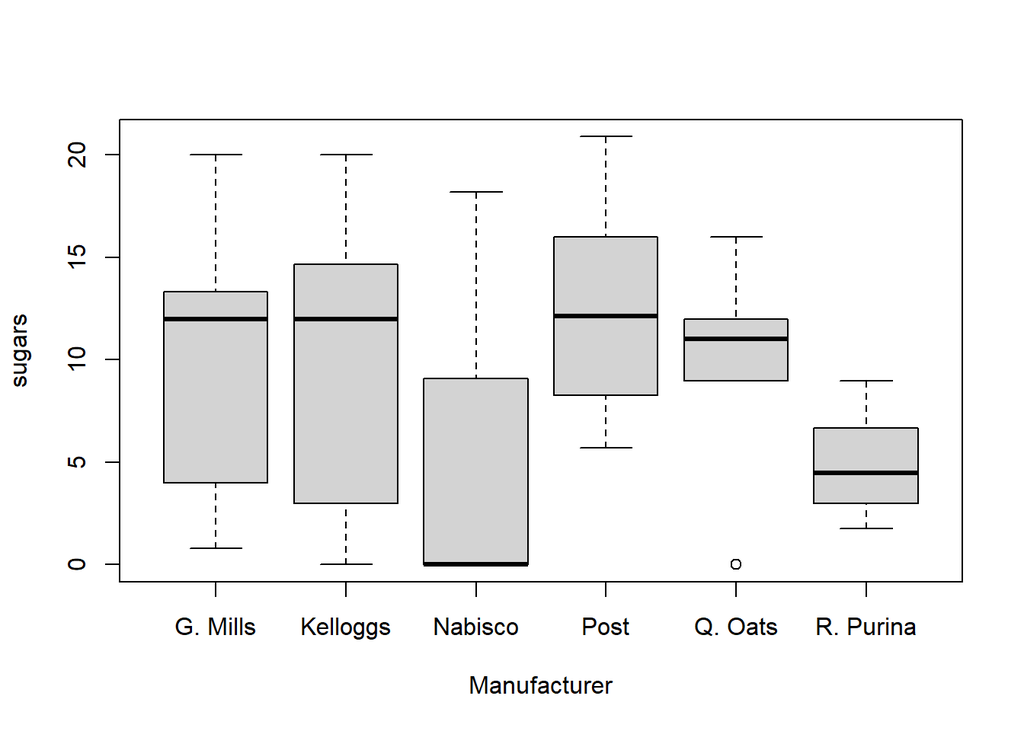

```r
> boxplot(sugars ~ mfr,
+         names = c("G. Mills", "Kelloggs", "Nabisco", "Post", "Q. Oats", "R. Purina"),
+         xlab = "Manufacturer")
```

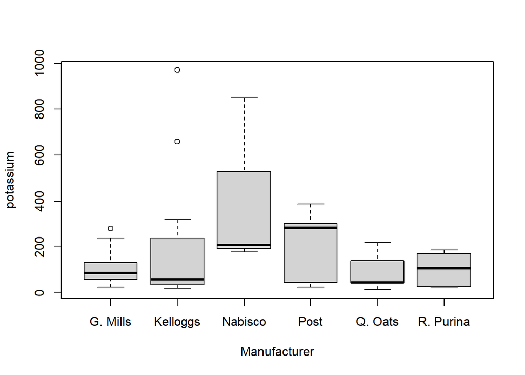

```r
> boxplot(potassium ~ mfr,
+         names = c("G. Mills", "Kelloggs", "Nabisco", "Post", "Q. Oats", "R. Purina"),
+         xlab = "Manufacturer")
```

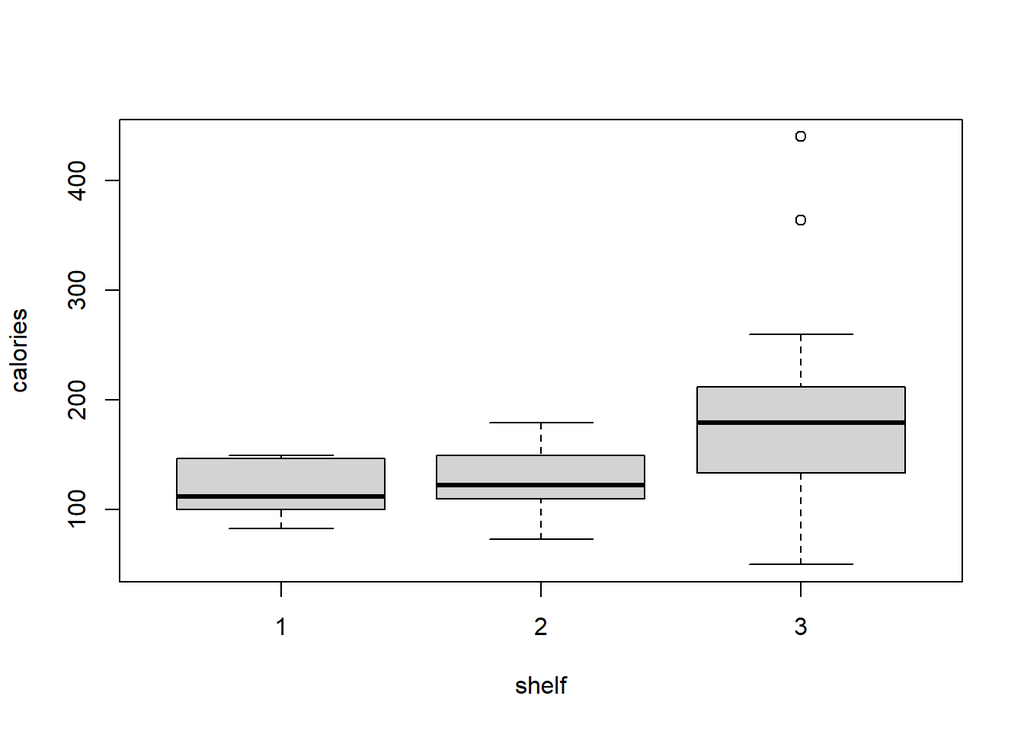

```r
> boxplot(calories ~ shelf)
```

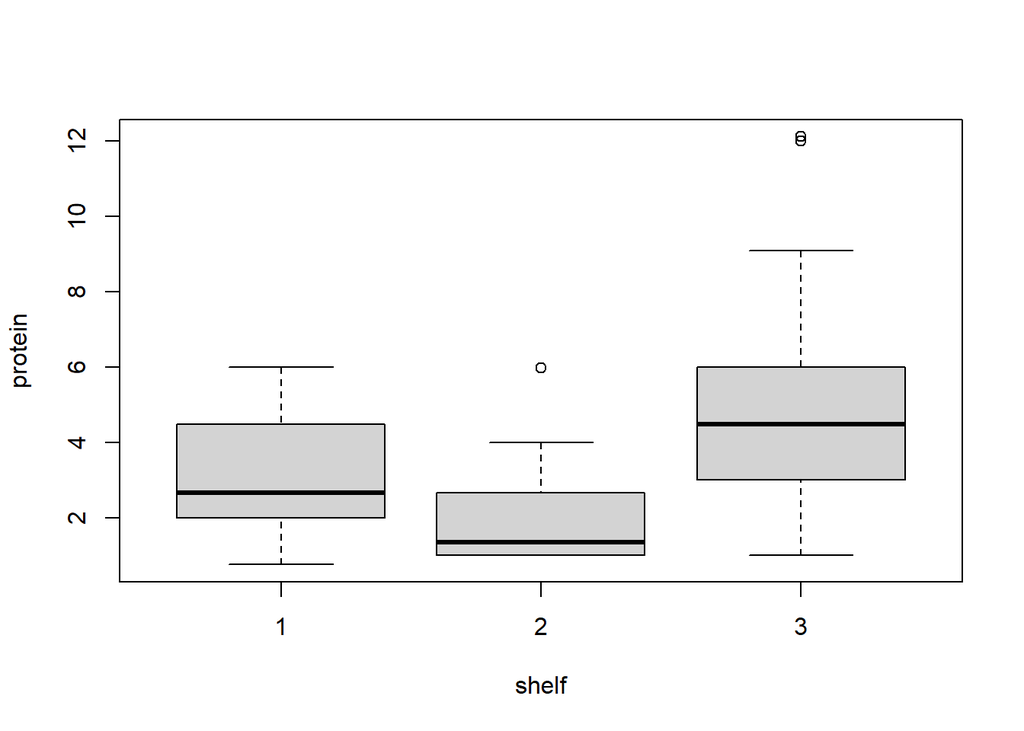

```r
> boxplot(protein ~ shelf)
```

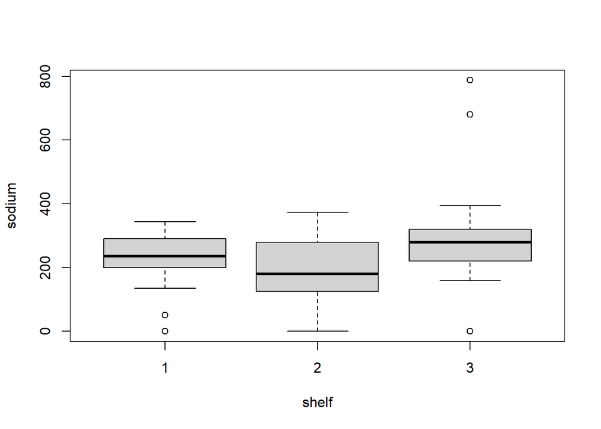

```r
> boxplot(sodium ~ shelf)
```

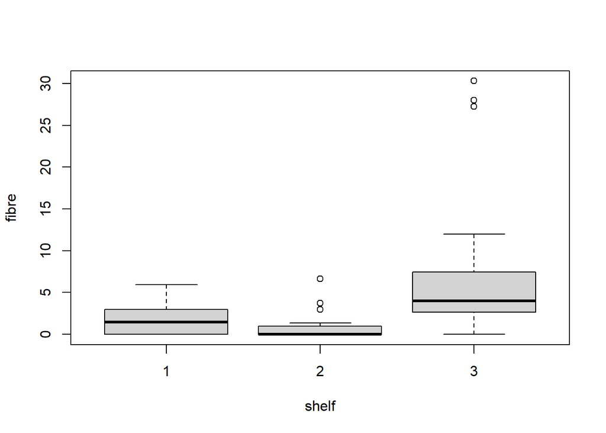

```r
> boxplot(fibre ~ shelf)
```

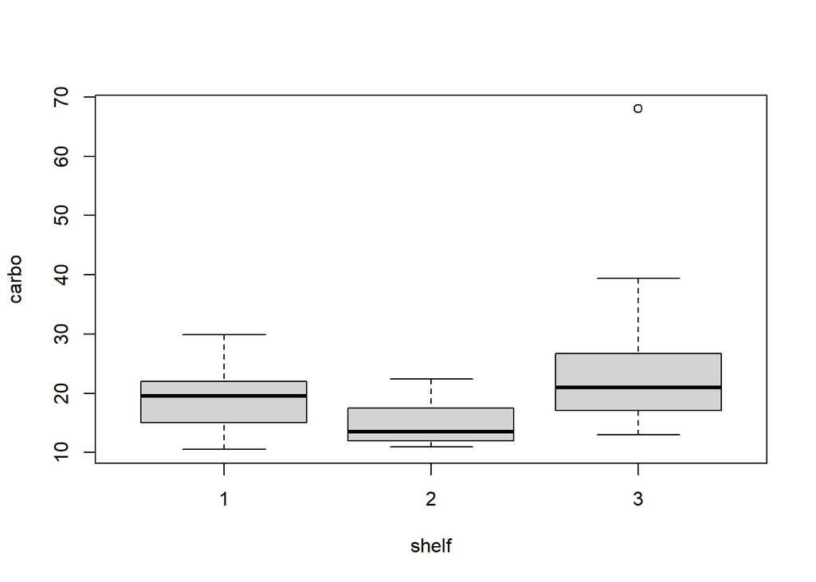

```r
> boxplot(carbo ~ shelf)
```

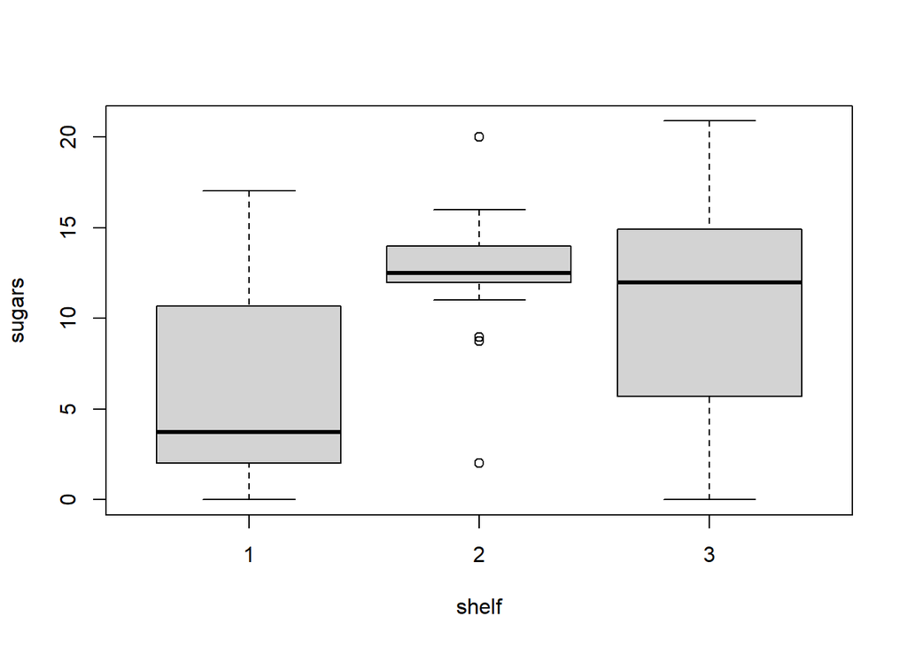

```r
> boxplot(sugars ~ shelf)
```

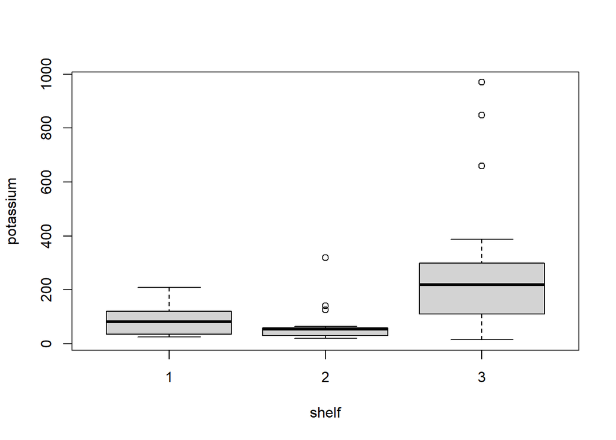

```r
> boxplot(potassium ~ shelf)
```

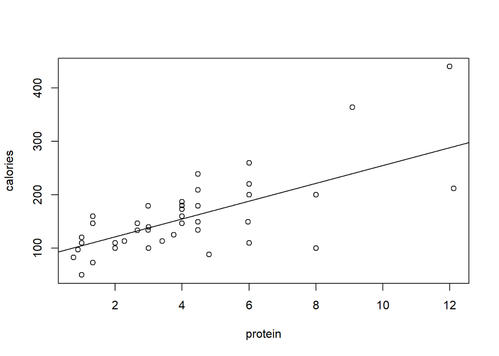

```r
> cor(protein, calories)
[1] 0.7060105
> plot(protein, calories)
> abline(lm(calories~protein))
```

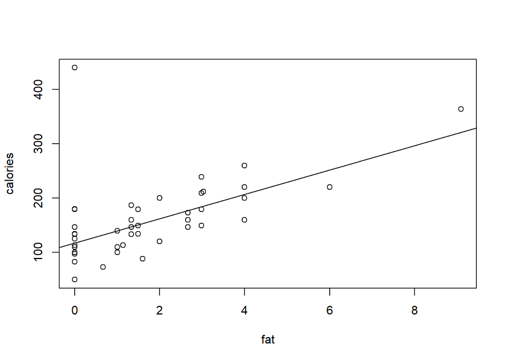

```r
> cor(fat, calories)
[1] 0.5901757
> plot(fat, calories)
> abline(lm(calories~fat))
```

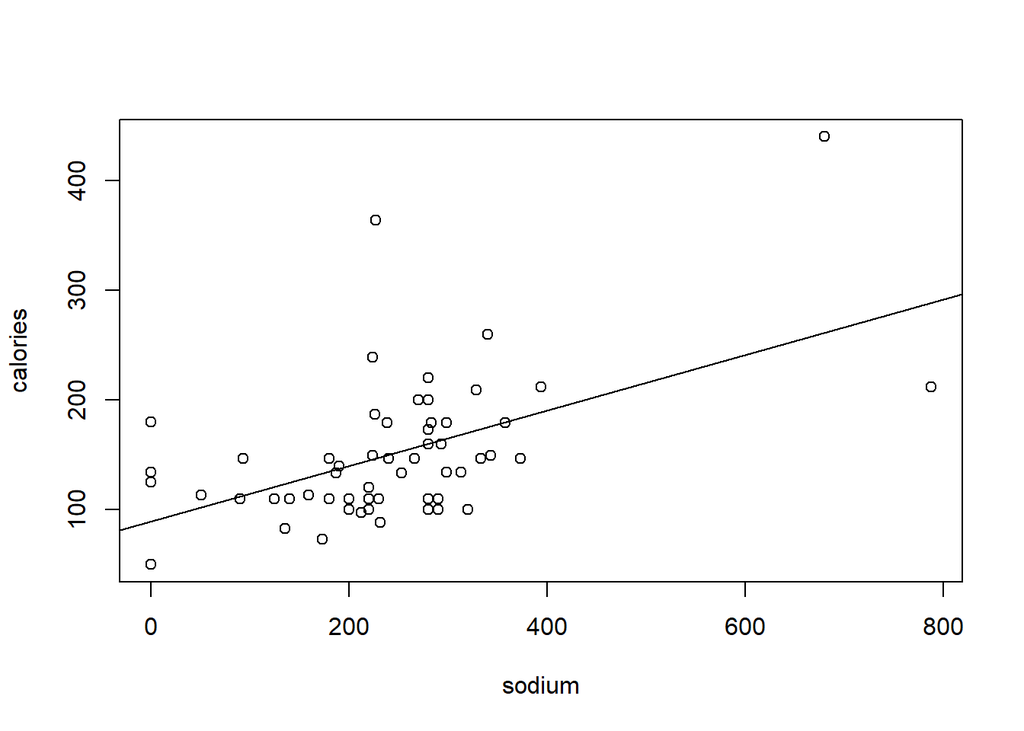

```r
> cor(sodium, calories)
[1] 0.5286552
> plot(sodium, calories)
> abline(lm(calories~sodium))
```

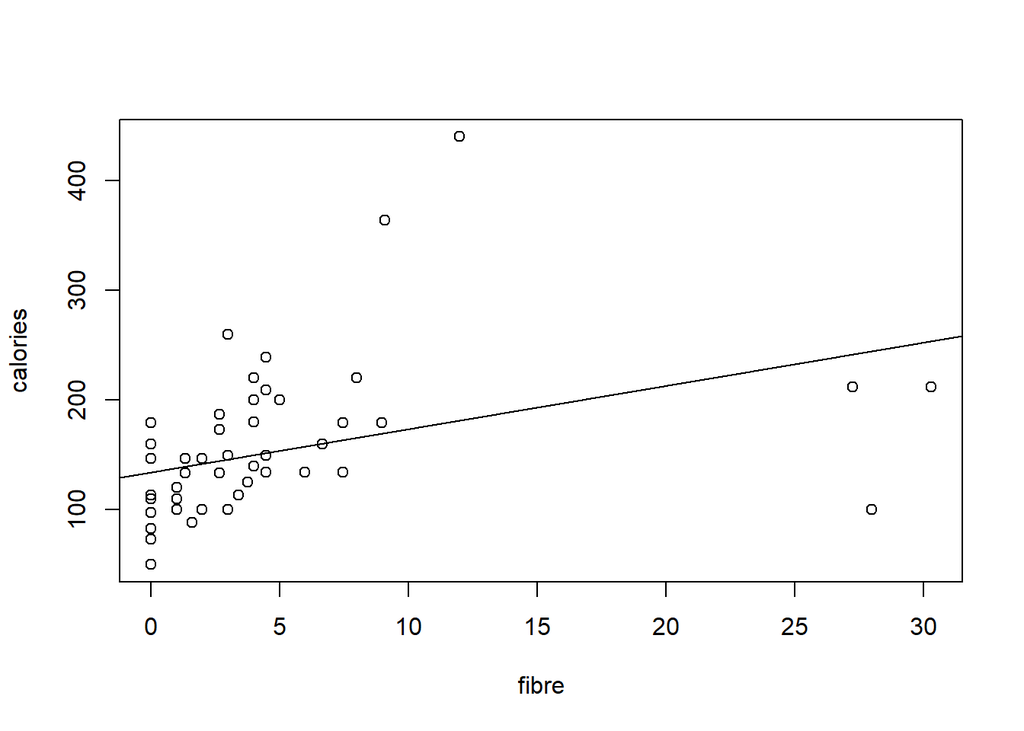

```r
> cor(fibre, calories)
[1] 0.3882179
> plot(fibre, calories)
> abline(lm(calories~fibre))
```

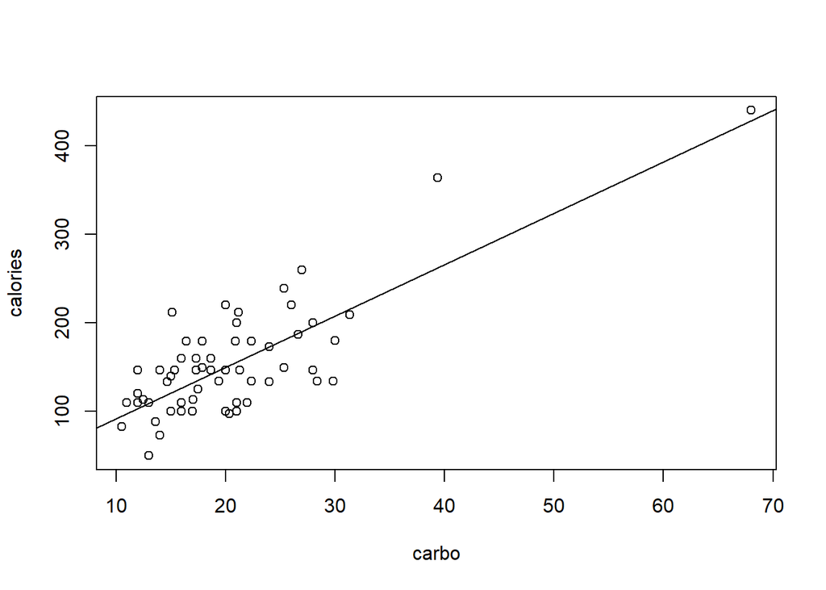

```r
> cor(carbo, calories)
[1] 0.7887227
> plot(carbo, calories)
> abline(lm(calories~carbo))
```

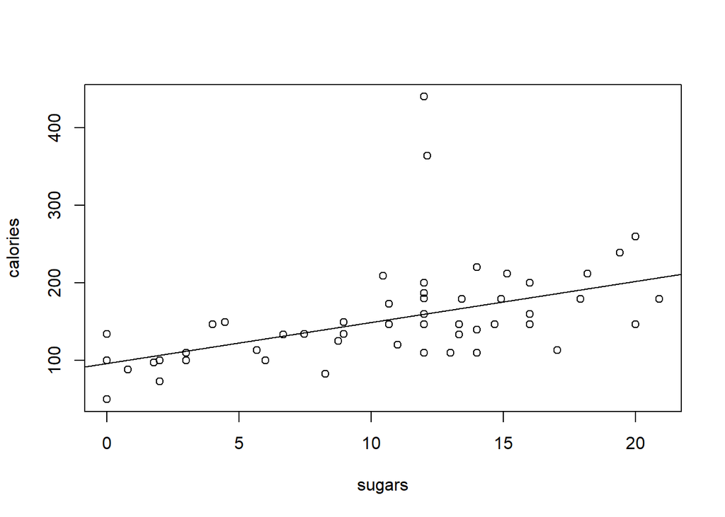

```r
> cor(sugars, calories)
[1] 0.4952942
> plot(sugars, calories)
> abline(lm(calories~sugars))
```

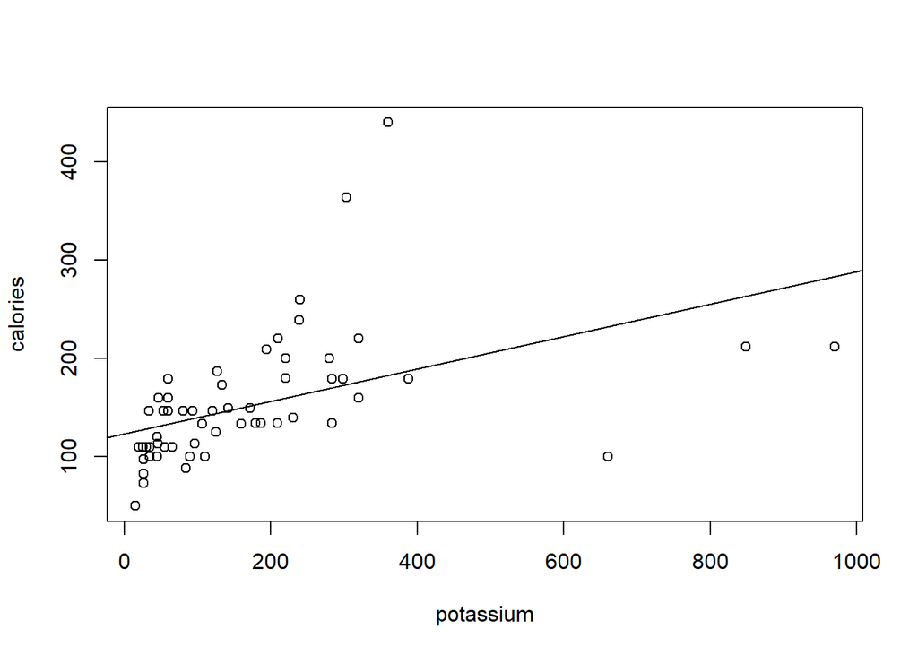

```r
> cor(potassium, calories)
[1] 0.4765955
> plot(potassium, calories)
> abline(lm(calories~potassium))
```